# Prediction Assignment Write up

Gian Carlo Sanfuego

2024-06-30

## Data Sources:

Training Data: Accessed from https://d396qusza40orc.cloudfront.net/predmachlearn/pml-training.csv Test Data: Accessed from https://d396qusza40orc.cloudfront.net/predmachlearn/pml-testing.csv

## Features:

Free up memory for download of the data sets

```r
rm(list = ls())
```

Get and set working directory

```r
setwd("D:/Desktop/DATA ANALYSIS/R/COURSE 8")
```

Define the list of packages to be installed

```r
packages <- c(
  "dplyr", "caret", "rpart", "rattle", "gbm", "randomForest", "e1071", "corrplot", "ggplot2", "data.table"
)
```

Install any packages that are not already installed

```r
installed_packages <- installed.packages()
for (pkg in packages) {
  if (!pkg %in% installed_packages[, "Package"]) {
    install.packages(pkg, dependencies = TRUE)
  }
}
```

Load all the packages

```r
lapply(packages, library, character.only = TRUE)
```

```
## This version of gbm is no longer under development. Consider transitioning to gbm3, https://github.com/gbm-developers/gbm3
```

[output not shown]

Read/Import datasets from the directory

```r
trainingdataset <- read.csv('pml-training.csv')
testingdataset <- read.csv('pml-testing.csv')
dim(trainingdataset)
```

```
## [1] 19622   160
```

```r
dim(testingdataset)
```

```
## [1]  20 160
```

Split the data into training and test sets

```r
set.seed(1967)
in_train  <- createDataPartition(trainingdataset$classe, p=0.80, list=FALSE)
train_train_set <- trainingdataset[ in_train, ]
train_test_set  <- trainingdataset[-in_train, ]
dim(train_train_set)
```

```
## [1] 15699   160
```

```r
dim(train_test_set)
```

```
## [1] 3923  160
```

Remove columns with mostly missing values with 90% threshold

```r
threshold <- 0.9
train_train_set <- train_train_set %>% select_if(~mean(is.na(.)) <= threshold)
train_test_set <- train_test_set %>% select_if(~mean(is.na(.)) <= threshold)
```

Remove also those variable with near zero variance

```r
nzv_var <- nearZeroVar(train_train_set)
train_train_set <- train_train_set[ , -nzv_var]
train_test_set  <- train_test_set[ , -nzv_var]
dim(train_train_set)
```

```
## [1] 15699    59
```

```r
dim(train_test_set)
```

```
## [1] 3923   59
```

Lets remove the first 5 columns since this is only ID column

```r
train_train_set <- train_train_set[ , -(1:5)]
train_test_set <- train_test_set[ , -(1:5)]
dim(train_train_set)
```

```
## [1] 15699    54
```

```r
dim(train_test_set)
```

```
## [1] 3923   54
```

Modeling Decision Tree

```r
modelDT <- rpart(classe ~ ., data = train_train_set, method="class")
summary(modelDT)
```

```
## Call:
## rpart(formula = classe ~ ., data = train_train_set, method = "class")
##   n= 15699
##
##            CP nsplit rel error    xerror        xstd
## 1  0.11624388      0 1.0000000 1.0000000 0.005030829
## 2  0.05500668      1 0.8837561 0.8852692 0.005373563
## 3  0.03916333      5 0.6637294 0.7139297 0.005574799
## 4  0.03079662      7 0.5854028 0.5967067 0.005516435
## 5  0.02705830      8 0.5546061 0.5594126 0.005464251
## 6  0.02380952      9 0.5275478 0.5399199 0.005430289
## 7  0.02314197     11 0.4799288 0.5051179 0.005357897
## 8  0.01967067     12 0.4567868 0.4830441 0.005303937
## 9  0.01406320     13 0.4371162 0.4322207 0.005154719
## 10 0.01397419     14 0.4230530 0.4144192 0.005093789
## 11 0.01361816     15 0.4090788 0.4112150 0.005082322
## 12 0.01228304     16 0.3954606 0.3911883 0.005007102
## 13 0.01112595     17 0.3831776 0.3691144 0.004916845
## 14 0.01014686     18 0.3720516 0.3626168 0.004888751
## 15 0.01000000     20 0.3517579 0.3515799 0.004839382
##
## Variable importance
##           num_window            roll_belt        pitch_forearm
##                   11                   11                    6
##           pitch_belt         accel_belt_z     accel_dumbbell_y
##                    6                    5                    4
##        roll_dumbbell total_accel_dumbbell    magnet_dumbbell_y
##                    4                    4                    4
##     total_accel_belt    magnet_dumbbell_z             yaw_belt
##                    4                    4                    3
##         roll_forearm      accel_forearm_x        magnet_belt_z
##                    3                    3                    3
##         accel_belt_y     accel_dumbbell_x        magnet_belt_x
##                    3                    2                    2
##         accel_belt_x    magnet_dumbbell_x         yaw_dumbbell
##                    2                    2                    2
##              yaw_arm     accel_dumbbell_z     magnet_forearm_x
##                    1                    1                    1
##        magnet_belt_y      accel_forearm_z     gyros_dumbbell_x
##                    1                    1                    1
```

[output cut: 450 more lines]

[output not shown]

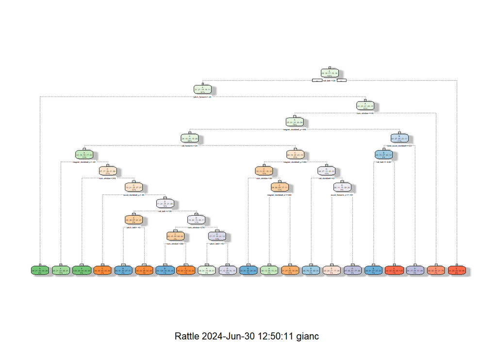

```r
fancyRpartPlot(modelDT)
```

Predict Decision Tree

```r
predict_DT <- predict(modelDT, newdata = train_test_set, type="class")
conf_matrix_DT <- confusionMatrix(table(predict_DT, train_test_set$classe))
conf_matrix_DT
```

```
## Confusion Matrix and Statistics
##
##
## predict_DT    A    B    C    D    E
##          A 1007  190   36   66   22
##          B   21  415   22   14   12
##          C    5   36  549   87   47
##          D   54   83   38  418   69
##          E   29   35   39   58  571
##
## Overall Statistics
##
##                Accuracy : 0.7545
##                  95% CI : (0.7407, 0.7679)
##     No Information Rate : 0.2845
##     P-Value [Acc > NIR] : < 2.2e-16
##
##                   Kappa : 0.6878
##
##  Mcnemar's Test P-Value : < 2.2e-16
##
## Statistics by Class:
##
##                      Class: A Class: B Class: C Class: D Class: E
## Sensitivity            0.9023   0.5468   0.8026   0.6501   0.7920
## Specificity            0.8881   0.9782   0.9460   0.9256   0.9497
## Pos Pred Value         0.7623   0.8574   0.7583   0.6314   0.7801
## Neg Pred Value         0.9581   0.9000   0.9578   0.9310   0.9530
## Prevalence             0.2845   0.1935   0.1744   0.1639   0.1838
## Detection Rate         0.2567   0.1058   0.1399   0.1066   0.1456
## Detection Prevalence   0.3367   0.1234   0.1846   0.1687   0.1866
## Balanced Accuracy      0.8952   0.7625   0.8743   0.7878   0.8708
```

Modeling GBM

```r
set.seed(1967)
ctrl_GBM <- trainControl(method = "repeatedcv", number = 5, repeats = 2)
modelGBM  <- train(classe ~ ., data = train_train_set, method = "gbm",
                  trControl = ctrl_GBM, verbose = FALSE)
modelGBM$finalModel
```

```
## A gradient boosted model with multinomial loss function.
## 150 iterations were performed.
## There were 53 predictors of which 53 had non-zero influence.
```

Predict using GBM

```r
predict_GBM <- predict(modelGBM, newdata = train_test_set)
conf_matrix_GBM <- confusionMatrix(table(predict_GBM, train_test_set$classe))
conf_matrix_GBM
```

```
## Confusion Matrix and Statistics
##
##
## predict_GBM    A    B    C    D    E
##           A 1113    9    0    1    0
##           B    3  744    4    0    1
##           C    0    5  677   12    2
##           D    0    1    3  630    7
##           E    0    0    0    0  711
##
## Overall Statistics
##
##                Accuracy : 0.9878
##                  95% CI : (0.9838, 0.991)
##     No Information Rate : 0.2845
##     P-Value [Acc > NIR] : < 2.2e-16
##
##                   Kappa : 0.9845
##
##  Mcnemar's Test P-Value : NA
##
## Statistics by Class:
##
##                      Class: A Class: B Class: C Class: D Class: E
## Sensitivity            0.9973   0.9802   0.9898   0.9798   0.9861
## Specificity            0.9964   0.9975   0.9941   0.9966   1.0000
## Pos Pred Value         0.9911   0.9894   0.9727   0.9828   1.0000
## Neg Pred Value         0.9989   0.9953   0.9978   0.9960   0.9969
## Prevalence             0.2845   0.1935   0.1744   0.1639   0.1838
## Detection Rate         0.2837   0.1897   0.1726   0.1606   0.1812
## Detection Prevalence   0.2863   0.1917   0.1774   0.1634   0.1812
## Balanced Accuracy      0.9969   0.9889   0.9920   0.9882   0.9931
```

Modeling Random Forest

```r
set.seed(1967)
ctrl_RF <- trainControl(method = "repeatedcv", number = 5, repeats = 2)
modelRF  <- train(classe ~ ., data = train_train_set, method = "rf",
                 trControl = ctrl_RF, verbose = FALSE)
modelRF$finalModel
```

```
##
## Call:
##  randomForest(x = x, y = y, mtry = param$mtry, verbose = FALSE)
##                Type of random forest: classification
##                      Number of trees: 500
## No. of variables tried at each split: 27
##
##         OOB estimate of  error rate: 0.18%
## Confusion matrix:
##      A    B    C    D    E  class.error
## A 4462    1    0    0    1 0.0004480287
## B    6 3028    3    1    0 0.0032916392
## C    0    5 2733    0    0 0.0018261505
## D    0    0    8 2565    0 0.0031092110
## E    0    0    0    3 2883 0.0010395010
```

Predict using Random Forest

```r
predict_RF <- predict(modelRF, newdata = train_test_set)
conf_matrix_RF <- confusionMatrix(table(predict_RF, train_test_set$classe))
conf_matrix_RF
```

```
## Confusion Matrix and Statistics
##
##
## predict_RF    A    B    C    D    E
##          A 1116    1    0    0    0
##          B    0  757    0    0    0
##          C    0    1  684    1    0
##          D    0    0    0  641    1
##          E    0    0    0    1  720
##
## Overall Statistics
##
##                Accuracy : 0.9987
##                  95% CI : (0.997, 0.9996)
##     No Information Rate : 0.2845
##     P-Value [Acc > NIR] : < 2.2e-16
##
##                   Kappa : 0.9984
##
##  Mcnemar's Test P-Value : NA
##
## Statistics by Class:
##
##                      Class: A Class: B Class: C Class: D Class: E
## Sensitivity            1.0000   0.9974   1.0000   0.9969   0.9986
## Specificity            0.9996   1.0000   0.9994   0.9997   0.9997
## Pos Pred Value         0.9991   1.0000   0.9971   0.9984   0.9986
## Neg Pred Value         1.0000   0.9994   1.0000   0.9994   0.9997
## Prevalence             0.2845   0.1935   0.1744   0.1639   0.1838
## Detection Rate         0.2845   0.1930   0.1744   0.1634   0.1835
## Detection Prevalence   0.2847   0.1930   0.1749   0.1637   0.1838
## Balanced Accuracy      0.9998   0.9987   0.9997   0.9983   0.9992
```

## Conclusion:

Accuracy: RF: 99.87% GBM: 98.78% DT: 75.45%

Random Forest is the best-performing model for this classification task. It achieves the highest accuracy, nearly perfect sensitivity and specificity, and the highest kappa, indicating that it is the most reliable and accurate model for predicting the activity data. Gradient Boosting Machine also performs very well, with high accuracy and kappa, making it a strong alternative to RF. It is slightly less accurate but still very robust in its predictions. Decision Tree has significantly lower accuracy and kappa compared to RF and GBM. While it can classify activities, it is less reliable and should be used with caution for this particular task.

```r
cat("Predictions: ", paste(predict(modelRF, testingdataset)))
```

```
## Predictions:  B A B A A E D B A A B C B A E E A B B B
```